# Case_study

Mariana Morales

## Introduction

Hello, the data for this case study comes from the Google Data Analyst Certificate. Through this case study, I demonstrate my ability to perform the six steps of the data analyst process and to use R programming to clean and analyze data.

## Scenario

Cyclistic is a fictional company based in Chicago that offers a total of 5,800 bicycles and 600 different docking stations. Cyclistic separates itself from other bike-share companies because it offers reclining bikes, hand tricycles, and cargo bikes which are inclusive of individuals with disabilities. Cyclistic makes it profit through two rider options, individuals can use bike as casual riders or as annual members. The marketing director thinks that the success of the company depends on maximizing the number of annual members. This analysis will focus on how annual members and casual riders use the application differently.

The report will include the following deliverables: 1. A clear statement of the business task 2. A description of all data sources used 3. Documentation of any cleaning or manipulation of data 4. A summary of your analysis 5. Supporting visualizations and key findings 6. Your top three recommendations based on your analysis

## Ask

How do annual members and casual riders use cyclistic bike differently?

Business Task: Determine the differences and similarities between casual riders and annual members use of cyclistic bike share.

## Prepare

Where is your data located? The Data for this Case Study is a public data set made available by Motivate International Inc under the licence https://ride.divvybikes.com/data-license-agreement. The data for last twelve months was downloaded and extracted from zipped file to a new folder in my computer to be used particularly for this case study.

Are there issues with bias or credibility in this data?

Does your data ROCCC? Reliable: Yes, Original: Yes, that data is first party data it was collected by the company itself. Comprehensive: Yes, the data sets are consistent and ready for cleaning. Current: The data is from the most recent twelve months, June 2021- May 2022. cited: https://ride.divvybikes.com/data-license-agreement.

How are you addressing licensing, privacy, security, and accessibility? The data for this case study is made available by Motivate International Inc under the licence aggreement https://ride.divvybikes.com/data-license-agreement. the data is used for this casestudy following licence agreement.

Is there any problems with the data? No, the data just needs to be further cleaned during process phase prior to analysis. Some of the ended_at times are before the started_at times signifying errors in the data.

How can data be used to provide insight? The started_at and ended_at columns could be used to perform calculation on mean, maximum, minimum, and median ride length to provide some understanding on how annual and casual riders use cyclistic differently. The casual_member column can be used to calculate the number or casual and annual members overall and each month and each day of the week.

## Process

R studio was used to clean and analyze the data. I chose R studio because the csv data files were very big and R studio allows us to create data frames and combine the twelve CSV files into one for further analysis. The combined data frame had about 6 million rows of data prior to further cleaning. Furthermore, Visulaization could be incorporated using ggplot2 from the tidyverse package. Plyr, and tidyverse packages were installed to clean and analyze the data.

load packages for data cleaning and analysis

```r
library(plyr)
library(lubridate)
library(tidyverse)
```

```r
library(readr)
library(dplyr)
library(ggplot2)
```

#### Import files for the last twelve months

use read_csv to upload csv files

```r
June <- read.csv("C:/Users/mml24/Downloads/CyclisticCaseStudy/June.csv")
July <- read.csv("C:/Users/mml24/Downloads/CyclisticCaseStudy/July.csv")
August <- read.csv("C:/Users/mml24/Downloads/CyclisticCaseStudy/August.csv")
September <- read.csv("C:/Users/mml24/Downloads/CyclisticCaseStudy/September.csv")
October <- read.csv("C:/Users/mml24/Downloads/CyclisticCaseStudy/October.csv")
November <- read.csv("C:/Users/mml24/Downloads/CyclisticCaseStudy/November.csv")
December <- read.csv("C:/Users/mml24/Downloads/CyclisticCaseStudy/December.csv")
January <- read.csv("C:/Users/mml24/Downloads/CyclisticCaseStudy/January.csv")
February <- read.csv("C:/Users/mml24/Downloads/CyclisticCaseStudy/February.csv")
March <- read.csv("C:/Users/mml24/Downloads/CyclisticCaseStudy/March.csv")
April <- read.csv("C:/Users/mml24/Downloads/CyclisticCaseStudy/April.csv")
May <- read.csv("C:/Users/mml24/Downloads/CyclisticCaseStudy/May.csv")
```

#### Inspect CSV files

use str(), glimplse(), and colnames() to check for compatablity and inconsistencies in data files.

```r
colnames(June)
```

```
##  [1] "ride_id"            "rideable_type"      "started_at"
##  [4] "ended_at"           "start_station_name" "start_station_id"
##  [7] "end_station_name"   "end_station_id"     "start_lat"
## [10] "start_lng"          "end_lat"            "end_lng"
## [13] "member_casual"
```

```r
colnames(July)
```

```
##  [1] "ride_id"            "rideable_type"      "started_at"
##  [4] "ended_at"           "start_station_name" "start_station_id"
##  [7] "end_station_name"   "end_station_id"     "start_lat"
## [10] "start_lng"          "end_lat"            "end_lng"
## [13] "member_casual"
```

```r
colnames(August)
```

```
##  [1] "ride_id"            "rideable_type"      "started_at"
##  [4] "ended_at"           "start_station_name" "start_station_id"
##  [7] "end_station_name"   "end_station_id"     "start_lat"
## [10] "start_lng"          "end_lat"            "end_lng"
## [13] "member_casual"
```

```r
colnames(September)
```

```
##  [1] "ride_id"            "rideable_type"      "started_at"
##  [4] "ended_at"           "start_station_name" "start_station_id"
##  [7] "end_station_name"   "end_station_id"     "start_lat"
## [10] "start_lng"          "end_lat"            "end_lng"
## [13] "member_casual"
```

```r
colnames(October)
```

```
##  [1] "ride_id"            "rideable_type"      "started_at"
##  [4] "ended_at"           "start_station_name" "start_station_id"
##  [7] "end_station_name"   "end_station_id"     "start_lat"
## [10] "start_lng"          "end_lat"            "end_lng"
## [13] "member_casual"
```

```r
colnames(November)
```

```
##  [1] "ride_id"            "rideable_type"      "started_at"
##  [4] "ended_at"           "start_station_name" "start_station_id"
##  [7] "end_station_name"   "end_station_id"     "start_lat"
## [10] "start_lng"          "end_lat"            "end_lng"
## [13] "member_casual"
```

```r
colnames(December)
```

```
##  [1] "ride_id"            "rideable_type"      "started_at"
##  [4] "ended_at"           "start_station_name" "start_station_id"
##  [7] "end_station_name"   "end_station_id"     "start_lat"
## [10] "start_lng"          "end_lat"            "end_lng"
## [13] "member_casual"
```

```r
colnames(January)
```

```
##  [1] "ride_id"            "rideable_type"      "started_at"
##  [4] "ended_at"           "start_station_name" "start_station_id"
##  [7] "end_station_name"   "end_station_id"     "start_lat"
## [10] "start_lng"          "end_lat"            "end_lng"
## [13] "member_casual"
```

```r
colnames(February)
```

```
##  [1] "ride_id"            "rideable_type"      "started_at"
##  [4] "ended_at"           "start_station_name" "start_station_id"
##  [7] "end_station_name"   "end_station_id"     "start_lat"
## [10] "start_lng"          "end_lat"            "end_lng"
## [13] "member_casual"
```

```r
colnames(March)
```

```
##  [1] "ride_id"            "rideable_type"      "started_at"
##  [4] "ended_at"           "start_station_name" "start_station_id"
##  [7] "end_station_name"   "end_station_id"     "start_lat"
## [10] "start_lng"          "end_lat"            "end_lng"
## [13] "member_casual"
```

```r
colnames(April)
```

```
##  [1] "ride_id"            "rideable_type"      "started_at"
##  [4] "ended_at"           "start_station_name" "start_station_id"
##  [7] "end_station_name"   "end_station_id"     "start_lat"
## [10] "start_lng"          "end_lat"            "end_lng"
## [13] "member_casual"
```

```r
colnames(May)
```

```
##  [1] "ride_id"            "rideable_type"      "started_at"
##  [4] "ended_at"           "start_station_name" "start_station_id"
##  [7] "end_station_name"   "end_station_id"     "start_lat"
## [10] "start_lng"          "end_lat"            "end_lng"
## [13] "member_casual"
```

```r
str(June)
```

```
## 'data.frame':    729595 obs. of  13 variables:
##  $ ride_id           : chr  "99FEC93BA843FB20" "06048DCFC8520CAF" "9598066F68045DF2" "B03C0FE48C412214" ...
##  $ rideable_type     : chr  "electric_bike" "electric_bike" "electric_bike" "electric_bike" ...
##  $ started_at        : chr  "6/13/2021 2:31:28 PM" "6/4/2021 11:18:02 AM" "6/4/2021 9:49:35 AM" "6/3/2021 7:56:05 PM" ...
##  $ ended_at          : chr  "6/13/2021 2:34:11 PM" "6/4/2021 11:24:19 AM" "6/4/2021 9:55:34 AM" "6/3/2021 8:21:55 PM" ...
##  $ start_station_name: chr  "" "" "" "" ...
##  $ start_station_id  : chr  "" "" "" "" ...
##  $ end_station_name  : chr  "" "" "" "" ...
##  $ end_station_id    : chr  "" "" "" "" ...
##  $ start_lat         : num  41.8 41.8 41.8 41.8 41.8 ...
##  $ start_lng         : num  -87.6 -87.6 -87.6 -87.6 -87.6 ...
##  $ end_lat           : num  41.8 41.8 41.8 41.8 41.8 ...
##  $ end_lng           : num  -87.6 -87.6 -87.6 -87.6 -87.6 ...
##  $ member_casual     : chr  "member" "member" "member" "member" ...
```

```r
str(July)
```

```
## 'data.frame':    822410 obs. of  13 variables:
##  $ ride_id           : chr  "0A1B623926EF4E16" "B2D5583A5A5E76EE" "6F264597DDBF427A" "379B58EAB20E8AA5" ...
##  $ rideable_type     : chr  "docked_bike" "classic_bike" "classic_bike" "classic_bike" ...
##  $ started_at        : chr  "7/2/2021 2:44:36 PM" "7/7/2021 4:57:42 PM" "7/25/2021 11:30:55 AM" "7/8/2021 10:08:30 PM" ...
##  $ ended_at          : chr  "7/2/2021 3:19:58 PM" "7/7/2021 5:16:09 PM" "7/25/2021 11:48:45 AM" "7/8/2021 10:23:32 PM" ...
##  $ start_station_name: chr  "Michigan Ave & Washington St" "California Ave & Cortez St" "Wabash Ave & 16th St" "California Ave & Cortez St" ...
##  $ start_station_id  : chr  "13001" "17660" "SL-012" "17660" ...
##  $ end_station_name  : chr  "Halsted St & North Branch St" "Wood St & Hubbard St" "Rush St & Hubbard St" "Carpenter St & Huron St" ...
##  $ end_station_id    : chr  "KA1504000117" "13432" "KA1503000044" "13196" ...
##  $ start_lat         : num  41.9 41.9 41.9 41.9 41.9 ...
##  $ start_lng         : num  -87.6 -87.7 -87.6 -87.7 -87.7 ...
##  $ end_lat           : num  41.9 41.9 41.9 41.9 41.9 ...
##  $ end_lng           : num  -87.6 -87.7 -87.6 -87.7 -87.7 ...
##  $ member_casual     : chr  "casual" "casual" "member" "member" ...
```

```r
str(August)
```

```
## 'data.frame':    600316 obs. of  13 variables:
##  $ ride_id           : chr  "99103BB87CC6C1BB" "EAFCCCFB0A3FC5A1" "9EF4F46C57AD234D" "5834D3208BFAF1DA" ...
##  $ rideable_type     : chr  "electric_bike" "electric_bike" "electric_bike" "electric_bike" ...
##  $ started_at        : chr  "8/10/2021 5:15:00 PM" "8/10/2021 5:23:00 PM" "8/21/2021 2:34:00 AM" "8/21/2021 6:52:00 AM" ...
##  $ ended_at          : chr  "8/10/2021 5:22:00 PM" "8/10/2021 5:39:00 PM" "8/21/2021 2:50:00 AM" "8/21/2021 7:08:00 AM" ...
##  $ start_station_name: chr  "" "" "" "" ...
##  $ start_station_id  : chr  "" "" "" "" ...
##  $ end_station_name  : chr  "" "" "" "" ...
##  $ end_station_id    : chr  "" "" "" "" ...
##  $ start_lat         : num  41.8 41.8 42 42 41.8 ...
##  $ start_lng         : num  -87.7 -87.7 -87.7 -87.7 -87.6 ...
##  $ end_lat           : num  41.8 41.8 42 42 41.8 ...
##  $ end_lng           : num  -87.7 -87.6 -87.7 -87.7 -87.6 ...
##  $ member_casual     : chr  "member" "member" "member" "member" ...
```

```r
str(September)
```

```
## 'data.frame':    756147 obs. of  13 variables:
##  $ ride_id           : chr  "9DC7B962304CBFD8" "F930E2C6872D6B32" "6EF72137900BB910" "78D1DE133B3DBF55" ...
##  $ rideable_type     : chr  "electric_bike" "electric_bike" "electric_bike" "electric_bike" ...
##  $ started_at        : chr  "9/28/2021 4:07:10 PM" "9/28/2021 2:24:51 PM" "9/28/2021 12:20:16 AM" "9/28/2021 2:51:17 PM" ...
##  $ ended_at          : chr  "9/28/2021 4:09:54 PM" "9/28/2021 2:40:05 PM" "9/28/2021 12:23:57 AM" "9/28/2021 3:00:06 PM" ...
##  $ start_station_name: chr  "" "" "" "" ...
##  $ start_station_id  : chr  "" "" "" "" ...
##  $ end_station_name  : chr  "" "" "" "" ...
##  $ end_station_id    : chr  "" "" "" "" ...
##  $ start_lat         : num  41.9 41.9 41.8 41.8 41.9 ...
##  $ start_lng         : num  -87.7 -87.6 -87.7 -87.7 -87.7 ...
##  $ end_lat           : num  41.9 42 41.8 41.8 41.9 ...
##  $ end_lng           : num  -87.7 -87.7 -87.7 -87.7 -87.7 ...
##  $ member_casual     : chr  "casual" "casual" "casual" "casual" ...
```

```r
str(October)
```

```
## 'data.frame':    631226 obs. of  13 variables:
##  $ ride_id           : chr  "620BC6107255BF4C" "4471C70731AB2E45" "26CA69D43D15EE14" "362947F0437E1514" ...
##  $ rideable_type     : chr  "electric_bike" "electric_bike" "electric_bike" "electric_bike" ...
##  $ started_at        : chr  "10/22/2021 12:46:42 PM" "10/21/2021 9:12:37 AM" "10/16/2021 4:28:39 PM" "10/16/2021 4:17:48 PM" ...
##  $ ended_at          : chr  "10/22/2021 12:49:50 PM" "10/21/2021 9:14:14 AM" "10/16/2021 4:36:26 PM" "10/16/2021 4:19:03 PM" ...
##  $ start_station_name: chr  "Kingsbury St & Kinzie St" "" "" "" ...
##  $ start_station_id  : chr  "KA1503000043" "" "" "" ...
##  $ end_station_name  : chr  "" "" "" "" ...
##  $ end_station_id    : chr  "" "" "" "" ...
##  $ start_lat         : num  41.9 41.9 41.9 41.9 41.9 ...
##  $ start_lng         : num  -87.6 -87.7 -87.7 -87.7 -87.7 ...
##  $ end_lat           : num  41.9 41.9 41.9 41.9 41.9 ...
##  $ end_lng           : num  -87.6 -87.7 -87.7 -87.7 -87.7 ...
##  $ member_casual     : chr  "member" "member" "member" "member" ...
```

```r
str(November)
```

```
## 'data.frame':    359978 obs. of  13 variables:
##  $ ride_id           : chr  "7C00A93E10556E47" "90854840DFD508BA" "0A7D10CDD144061C" "2F3BE33085BCFF02" ...
##  $ rideable_type     : chr  "electric_bike" "electric_bike" "electric_bike" "electric_bike" ...
##  $ started_at        : chr  "11/27/2021 1:27:38 PM" "11/27/2021 1:38:00 PM" "11/26/2021 10:03:00 PM" "11/27/2021 9:56:00 AM" ...
##  $ ended_at          : chr  "11/27/2021 1:46:38 PM" "11/27/2021 1:56:10 PM" "11/26/2021 10:05:56 PM" "11/27/2021 10:01:50 AM" ...
##  $ start_station_name: chr  "" "" "" "" ...
##  $ start_station_id  : chr  "" "" "" "" ...
##  $ end_station_name  : chr  "" "" "" "" ...
##  $ end_station_id    : chr  "" "" "" "" ...
##  $ start_lat         : num  41.9 42 42 41.9 41.9 ...
##  $ start_lng         : num  -87.7 -87.7 -87.7 -87.8 -87.6 ...
##  $ end_lat           : num  42 41.9 42 41.9 41.9 ...
##  $ end_lng           : num  -87.7 -87.7 -87.7 -87.8 -87.6 ...
##  $ member_casual     : chr  "casual" "casual" "casual" "casual" ...
```

```r
str(December)
```

```
## 'data.frame':    247540 obs. of  13 variables:
##  $ ride_id           : chr  "46F8167220E4431F" "73A77762838B32FD" "4CF42452054F59C5" "3278BA87BF698339" ...
##  $ rideable_type     : chr  "electric_bike" "electric_bike" "electric_bike" "classic_bike" ...
##  $ started_at        : chr  "12/7/2021 3:06:07 PM" "12/11/2021 3:43:29 AM" "12/15/2021 11:10:28 PM" "12/26/2021 4:16:10 PM" ...
##  $ ended_at          : chr  "12/7/2021 3:13:42 PM" "12/11/2021 4:10:23 AM" "12/15/2021 11:23:14 PM" "12/26/2021 4:30:53 PM" ...
##  $ start_station_name: chr  "Laflin St & Cullerton St" "LaSalle Dr & Huron St" "Halsted St & North Branch St" "Halsted St & North Branch St" ...
##  $ start_station_id  : chr  "13307" "KP1705001026" "KA1504000117" "KA1504000117" ...
##  $ end_station_name  : chr  "Morgan St & Polk St" "Clarendon Ave & Leland Ave" "Broadway & Barry Ave" "LaSalle Dr & Huron St" ...
##  $ end_station_id    : chr  "TA1307000130" "TA1307000119" "13137" "KP1705001026" ...
##  $ start_lat         : num  41.9 41.9 41.9 41.9 41.9 ...
##  $ start_lng         : num  -87.7 -87.6 -87.6 -87.6 -87.7 ...
##  $ end_lat           : num  41.9 42 41.9 41.9 41.9 ...
##  $ end_lng           : num  -87.7 -87.7 -87.6 -87.6 -87.6 ...
##  $ member_casual     : chr  "member" "casual" "member" "member" ...
```

```r
str(January)
```

```
## 'data.frame':    103770 obs. of  13 variables:
##  $ ride_id           : chr  "C2F7DD78E82EC875" "A6CF8980A652D272" "BD0F91DFF741C66D" "CBB80ED419105406" ...
##  $ rideable_type     : chr  "electric_bike" "electric_bike" "classic_bike" "classic_bike" ...
##  $ started_at        : chr  "1/13/2022 11:59:47 AM" "1/10/2022 8:41:56 AM" "1/25/2022 4:53:40 AM" "1/4/2022 12:18:04 AM" ...
##  $ ended_at          : chr  "1/13/2022 12:02:44 PM" "1/10/2022 8:46:17 AM" "1/25/2022 4:58:01 AM" "1/4/2022 12:33:00 AM" ...
##  $ start_station_name: chr  "Glenwood Ave & Touhy Ave" "Glenwood Ave & Touhy Ave" "Sheffield Ave & Fullerton Ave" "Clark St & Bryn Mawr Ave" ...
##  $ start_station_id  : chr  "525" "525" "TA1306000016" "KA1504000151" ...
##  $ end_station_name  : chr  "Clark St & Touhy Ave" "Clark St & Touhy Ave" "Greenview Ave & Fullerton Ave" "Paulina St & Montrose Ave" ...
##  $ end_station_id    : chr  "RP-007" "RP-007" "TA1307000001" "TA1309000021" ...
##  $ start_lat         : num  42 42 41.9 42 41.9 ...
##  $ start_lng         : num  -87.7 -87.7 -87.7 -87.7 -87.6 ...
##  $ end_lat           : num  42 42 41.9 42 41.9 ...
##  $ end_lng           : num  -87.7 -87.7 -87.7 -87.7 -87.6 ...
##  $ member_casual     : chr  "casual" "casual" "member" "casual" ...
```

```r
str(February)
```

```
## 'data.frame':    115609 obs. of  13 variables:
##  $ ride_id           : chr  "E1E065E7ED285C02" "1602DCDC5B30FFE3" "BE7DD2AF4B55C4AF" "A1789BDF844412BE" ...
##  $ rideable_type     : chr  "classic_bike" "classic_bike" "classic_bike" "classic_bike" ...
##  $ started_at        : chr  "2/19/2022 6:08:41 PM" "2/20/2022 5:41:30 PM" "2/25/2022 6:55:56 PM" "2/14/2022 11:57:03 AM" ...
##  $ ended_at          : chr  "2/19/2022 6:23:56 PM" "2/20/2022 5:45:56 PM" "2/25/2022 7:09:34 PM" "2/14/2022 12:04:00 PM" ...
##  $ start_station_name: chr  "State St & Randolph St" "Halsted St & Wrightwood Ave" "State St & Randolph St" "Southport Ave & Waveland Ave" ...
##  $ start_station_id  : chr  "TA1305000029" "TA1309000061" "TA1305000029" "13235" ...
##  $ end_station_name  : chr  "Clark St & Lincoln Ave" "Southport Ave & Wrightwood Ave" "Canal St & Adams St" "Broadway & Sheridan Rd" ...
##  $ end_station_id    : chr  "13179" "TA1307000113" "13011" "13323" ...
##  $ start_lat         : num  41.9 41.9 41.9 41.9 41.9 ...
##  $ start_lng         : num  -87.6 -87.6 -87.6 -87.7 -87.6 ...
##  $ end_lat           : num  41.9 41.9 41.9 42 41.9 ...
##  $ end_lng           : num  -87.6 -87.7 -87.6 -87.6 -87.6 ...
##  $ member_casual     : chr  "member" "member" "member" "member" ...
```

```r
str(March)
```

```
## 'data.frame':    284042 obs. of  13 variables:
##  $ ride_id           : chr  "47EC0A7F82E65D52" "8494861979B0F477" "EFE527AF80B66109" "9F446FD9DEE3F389" ...
##  $ rideable_type     : chr  "classic_bike" "electric_bike" "classic_bike" "classic_bike" ...
##  $ started_at        : chr  "3/21/2022 1:45:01 PM" "3/16/2022 9:37:16 AM" "3/23/2022 7:52:02 PM" "3/1/2022 7:12:26 PM" ...
##  $ ended_at          : chr  "3/21/2022 1:51:18 PM" "3/16/2022 9:43:34 AM" "3/23/2022 7:54:48 PM" "3/1/2022 7:22:14 PM" ...
##  $ start_station_name: chr  "Wabash Ave & Wacker Pl" "Michigan Ave & Oak St" "Broadway & Berwyn Ave" "Wabash Ave & Wacker Pl" ...
##  $ start_station_id  : chr  "TA1307000131" "13042" "13109" "TA1307000131" ...
##  $ end_station_name  : chr  "Kingsbury St & Kinzie St" "Orleans St & Chestnut St (NEXT Apts)" "Broadway & Ridge Ave" "Franklin St & Jackson Blvd" ...
##  $ end_station_id    : chr  "KA1503000043" "620" "15578" "TA1305000025" ...
##  $ start_lat         : num  41.9 41.9 42 41.9 41.9 ...
##  $ start_lng         : num  -87.6 -87.6 -87.7 -87.6 -87.6 ...
##  $ end_lat           : num  41.9 41.9 42 41.9 41.9 ...
##  $ end_lng           : num  -87.6 -87.6 -87.7 -87.6 -87.7 ...
##  $ member_casual     : chr  "member" "member" "member" "member" ...
```

```r
str(April)
```

```
## 'data.frame':    371249 obs. of  13 variables:
##  $ ride_id           : chr  "3564070EEFD12711" "0B820C7FCF22F489" "89EEEE32293F07FF" "84D4751AEB31888D" ...
##  $ rideable_type     : chr  "electric_bike" "classic_bike" "classic_bike" "classic_bike" ...
##  $ started_at        : chr  "4/6/2022 5:42:48 PM" "4/24/2022 7:23:00 PM" "4/20/2022 7:29:00 PM" "4/22/2022 9:14:00 PM" ...
##  $ ended_at          : chr  "4/6/2022 5:54:36 PM" "4/24/2022 7:43:17 PM" "4/20/2022 7:35:16 PM" "4/22/2022 9:23:29 PM" ...
##  $ start_station_name: chr  "Paulina St & Howard St" "Wentworth Ave & Cermak Rd" "Halsted St & Polk St" "Wentworth Ave & Cermak Rd" ...
##  $ start_station_id  : chr  "515" "13075" "TA1307000121" "13075" ...
##  $ end_station_name  : chr  "University Library (NU)" "Green St & Madison St" "Green St & Madison St" "Delano Ct & Roosevelt Rd" ...
##  $ end_station_id    : chr  "605" "TA1307000120" "TA1307000120" "KA1706005007" ...
##  $ start_lat         : num  42 41.9 41.9 41.9 41.9 ...
##  $ start_lng         : num  -87.7 -87.6 -87.6 -87.6 -87.6 ...
##  $ end_lat           : num  42.1 41.9 41.9 41.9 41.9 ...
##  $ end_lng           : num  -87.7 -87.6 -87.6 -87.6 -87.6 ...
##  $ member_casual     : chr  "member" "member" "member" "casual" ...
```

```r
str(May)
```

```
## 'data.frame':    634858 obs. of  13 variables:
##  $ ride_id           : chr  "EC2DE40644C6B0F4" "1C31AD03897EE385" "1542FBEC830415CF" "6FF59852924528F8" ...
##  $ rideable_type     : chr  "classic_bike" "classic_bike" "classic_bike" "classic_bike" ...
##  $ started_at        : chr  "5/23/2022 23:06" "5/11/2022 8:53" "5/26/2022 18:36" "5/10/2022 7:30" ...
##  $ ended_at          : chr  "5/23/2022 23:40" "5/11/2022 9:31" "5/26/2022 18:58" "5/10/2022 7:38" ...
##  $ start_station_name: chr  "Wabash Ave & Grand Ave" "DuSable Lake Shore Dr & Monroe St" "Clinton St & Madison St" "Clinton St & Madison St" ...
##  $ start_station_id  : chr  "TA1307000117" "13300" "TA1305000032" "TA1305000032" ...
##  $ end_station_name  : chr  "Halsted St & Roscoe St" "Field Blvd & South Water St" "Wood St & Milwaukee Ave" "Clark St & Randolph St" ...
##  $ end_station_id    : chr  "TA1309000025" "15534" "13221" "TA1305000030" ...
##  $ start_lat         : num  41.9 41.9 41.9 41.9 41.9 ...
##  $ start_lng         : num  -87.6 -87.6 -87.6 -87.6 -87.6 ...
##  $ end_lat           : num  41.9 41.9 41.9 41.9 41.9 ...
##  $ end_lng           : num  -87.6 -87.6 -87.7 -87.6 -87.7 ...
##  $ member_casual     : chr  "member" "member" "member" "member" ...
```

```r
glimpse(June)
```

```
## Rows: 729,595
## Columns: 13
## $ ride_id            <chr> "99FEC93BA843FB20", "06048DCFC8520CAF", "9598066F68…
## $ rideable_type      <chr> "electric_bike", "electric_bike", "electric_bike", …
## $ started_at         <chr> "6/13/2021 2:31:28 PM", "6/4/2021 11:18:02 AM", "6/…
## $ ended_at           <chr> "6/13/2021 2:34:11 PM", "6/4/2021 11:24:19 AM", "6/…
## $ start_station_name <chr> "", "", "", "", "", "", "", "", "", "", "", "", "",…
## $ start_station_id   <chr> "", "", "", "", "", "", "", "", "", "", "", "", "",…
## $ end_station_name   <chr> "", "", "", "", "", "", "", "", "", "Michigan Ave &…
## $ end_station_id     <chr> "", "", "", "", "", "", "", "", "", "13042", "", ""…
## $ start_lat          <dbl> 41.80, 41.79, 41.80, 41.78, 41.80, 41.78, 41.79, 41…
## $ start_lng          <dbl> -87.59, -87.59, -87.60, -87.58, -87.59, -87.58, -87…
## $ end_lat            <dbl> 41.80000, 41.80000, 41.79000, 41.80000, 41.79000, 4…
## $ end_lng            <dbl> -87.6000, -87.6000, -87.5900, -87.6000, -87.5900, -…
## $ member_casual      <chr> "member", "member", "member", "member", "member", "…
```

```r
glimpse(July)
```

```
## Rows: 822,410
## Columns: 13
## $ ride_id            <chr> "0A1B623926EF4E16", "B2D5583A5A5E76EE", "6F264597DD…
## $ rideable_type      <chr> "docked_bike", "classic_bike", "classic_bike", "cla…
## $ started_at         <chr> "7/2/2021 2:44:36 PM", "7/7/2021 4:57:42 PM", "7/25…
## $ ended_at           <chr> "7/2/2021 3:19:58 PM", "7/7/2021 5:16:09 PM", "7/25…
## $ start_station_name <chr> "Michigan Ave & Washington St", "California Ave & C…
## $ start_station_id   <chr> "13001", "17660", "SL-012", "17660", "17660", "1766…
## $ end_station_name   <chr> "Halsted St & North Branch St", "Wood St & Hubbard …
## $ end_station_id     <chr> "KA1504000117", "13432", "KA1503000044", "13196", "…
## $ start_lat          <dbl> 41.88398, 41.90036, 41.86038, 41.90036, 41.90035, 4…
## $ start_lng          <dbl> -87.62468, -87.69670, -87.62581, -87.69670, -87.696…
## $ end_lat            <dbl> 41.89937, 41.88990, 41.89017, 41.89456, 41.88659, 4…
## $ end_lng            <dbl> -87.64848, -87.67147, -87.62619, -87.65345, -87.658…
## $ member_casual      <chr> "casual", "casual", "member", "member", "casual", "…
```

```r
glimpse(August)
```

```
## Rows: 600,316
## Columns: 13
## $ ride_id            <chr> "99103BB87CC6C1BB", "EAFCCCFB0A3FC5A1", "9EF4F46C57…
## $ rideable_type      <chr> "electric_bike", "electric_bike", "electric_bike", …
## $ started_at         <chr> "8/10/2021 5:15:00 PM", "8/10/2021 5:23:00 PM", "8/…
## $ ended_at           <chr> "8/10/2021 5:22:00 PM", "8/10/2021 5:39:00 PM", "8/…
## $ start_station_name <chr> "", "", "", "", "", "", "", "", "", "", "", "", "",…
## $ start_station_id   <chr> "", "", "", "", "", "", "", "", "", "", "", "", "",…
## $ end_station_name   <chr> "", "", "", "", "", "", "", "Clark St & Grace St", …
## $ end_station_id     <chr> "", "", "", "", "", "", "", "TA1307000127", "", "",…
## $ start_lat          <dbl> 41.77000, 41.77000, 41.95000, 41.97000, 41.79000, 4…
## $ start_lng          <dbl> -87.68000, -87.68000, -87.65000, -87.67000, -87.600…
## $ end_lat            <dbl> 41.77000, 41.77000, 41.97000, 41.95000, 41.77000, 4…
## $ end_lng            <dbl> -87.68000, -87.63000, -87.66000, -87.65000, -87.620…
## $ member_casual      <chr> "member", "member", "member", "member", "member", "…
```

```r
glimpse(September)
```

```
## Rows: 756,147
## Columns: 13
## $ ride_id            <chr> "9DC7B962304CBFD8", "F930E2C6872D6B32", "6EF7213790…
## $ rideable_type      <chr> "electric_bike", "electric_bike", "electric_bike", …
## $ started_at         <chr> "9/28/2021 4:07:10 PM", "9/28/2021 2:24:51 PM", "9/…
## $ ended_at           <chr> "9/28/2021 4:09:54 PM", "9/28/2021 2:40:05 PM", "9/…
## $ start_station_name <chr> "", "", "", "", "", "", "", "", "", "", "Clark St &…
## $ start_station_id   <chr> "", "", "", "", "", "", "", "", "", "", "TA13070001…
## $ end_station_name   <chr> "", "", "", "", "", "", "", "", "", "", "", "", "",…
## $ end_station_id     <chr> "", "", "", "", "", "", "", "", "", "", "", "", "",…
## $ start_lat          <dbl> 41.89000, 41.94000, 41.81000, 41.80000, 41.88000, 4…
## $ start_lng          <dbl> -87.68000, -87.64000, -87.72000, -87.72000, -87.740…
## $ end_lat            <dbl> 41.89, 41.98, 41.80, 41.81, 41.88, 41.88, 41.74, 41…
## $ end_lng            <dbl> -87.67, -87.67, -87.72, -87.72, -87.71, -87.74, -87…
## $ member_casual      <chr> "casual", "casual", "casual", "casual", "casual", "…
```

```r
glimpse(October)
```

```
## Rows: 631,226
## Columns: 13
## $ ride_id            <chr> "620BC6107255BF4C", "4471C70731AB2E45", "26CA69D43D…
## $ rideable_type      <chr> "electric_bike", "electric_bike", "electric_bike", …
## $ started_at         <chr> "10/22/2021 12:46:42 PM", "10/21/2021 9:12:37 AM", …
## $ ended_at           <chr> "10/22/2021 12:49:50 PM", "10/21/2021 9:14:14 AM", …
## $ start_station_name <chr> "Kingsbury St & Kinzie St", "", "", "", "", "", "",…
## $ start_station_id   <chr> "KA1503000043", "", "", "", "", "", "", "", "", "",…
## $ end_station_name   <chr> "", "", "", "", "", "", "", "", "", "", "", "", "",…
## $ end_station_id     <chr> "", "", "", "", "", "", "", "", "", "", "", "", "",…
## $ start_lat          <dbl> 41.88919, 41.93000, 41.92000, 41.92000, 41.89000, 4…
## $ start_lng          <dbl> -87.63850, -87.70000, -87.70000, -87.69000, -87.710…
## $ end_lat            <dbl> 41.89000, 41.93000, 41.94000, 41.92000, 41.89000, 4…
## $ end_lng            <dbl> -87.63000, -87.71000, -87.72000, -87.69000, -87.690…
## $ member_casual      <chr> "member", "member", "member", "member", "member", "…
```

```r
glimpse(November)
```

```
## Rows: 359,978
## Columns: 13
## $ ride_id            <chr> "7C00A93E10556E47", "90854840DFD508BA", "0A7D10CDD1…
## $ rideable_type      <chr> "electric_bike", "electric_bike", "electric_bike", …
## $ started_at         <chr> "11/27/2021 1:27:38 PM", "11/27/2021 1:38:00 PM", "…
## $ ended_at           <chr> "11/27/2021 1:46:38 PM", "11/27/2021 1:56:10 PM", "…
## $ start_station_name <chr> "", "", "", "", "", "Michigan Ave & Oak St", "", ""…
## $ start_station_id   <chr> "", "", "", "", "", "13042", "", "", "", "", "", ""…
## $ end_station_name   <chr> "", "", "", "", "", "", "", "", "", "", "", "", "",…
## $ end_station_id     <chr> "", "", "", "", "", "", "", "", "", "", "", "", "",…
## $ start_lat          <dbl> 41.93000, 41.96000, 41.96000, 41.94000, 41.90000, 4…
## $ start_lng          <dbl> -87.72000, -87.70000, -87.70000, -87.79000, -87.630…
## $ end_lat            <dbl> 41.96, 41.92, 41.96, 41.93, 41.88, 41.90, 41.80, 41…
## $ end_lng            <dbl> -87.73, -87.70, -87.70, -87.79, -87.62, -87.63, -87…
## $ member_casual      <chr> "casual", "casual", "casual", "casual", "casual", "…
```

```r
glimpse(December)
```

```
## Rows: 247,540
## Columns: 13
## $ ride_id            <chr> "46F8167220E4431F", "73A77762838B32FD", "4CF4245205…
## $ rideable_type      <chr> "electric_bike", "electric_bike", "electric_bike", …
## $ started_at         <chr> "12/7/2021 3:06:07 PM", "12/11/2021 3:43:29 AM", "1…
## $ ended_at           <chr> "12/7/2021 3:13:42 PM", "12/11/2021 4:10:23 AM", "1…
## $ start_station_name <chr> "Laflin St & Cullerton St", "LaSalle Dr & Huron St"…
## $ start_station_id   <chr> "13307", "KP1705001026", "KA1504000117", "KA1504000…
## $ end_station_name   <chr> "Morgan St & Polk St", "Clarendon Ave & Leland Ave"…
## $ end_station_id     <chr> "TA1307000130", "TA1307000119", "13137", "KP1705001…
## $ start_lat          <dbl> 41.85483, 41.89441, 41.89936, 41.89939, 41.89558, 4…
## $ start_lng          <dbl> -87.66366, -87.63233, -87.64852, -87.64854, -87.682…
## $ end_lat            <dbl> 41.87197, 41.96797, 41.93758, 41.89488, 41.93125, 4…
## $ end_lng            <dbl> -87.65097, -87.65000, -87.64410, -87.63233, -87.644…
## $ member_casual      <chr> "member", "casual", "member", "member", "member", "…
```

```r
glimpse(January)
```

```
## Rows: 103,770
## Columns: 13
## $ ride_id            <chr> "C2F7DD78E82EC875", "A6CF8980A652D272", "BD0F91DFF7…
## $ rideable_type      <chr> "electric_bike", "electric_bike", "classic_bike", "…
## $ started_at         <chr> "1/13/2022 11:59:47 AM", "1/10/2022 8:41:56 AM", "1…
## $ ended_at           <chr> "1/13/2022 12:02:44 PM", "1/10/2022 8:46:17 AM", "1…
## $ start_station_name <chr> "Glenwood Ave & Touhy Ave", "Glenwood Ave & Touhy A…
## $ start_station_id   <chr> "525", "525", "TA1306000016", "KA1504000151", "TA13…
## $ end_station_name   <chr> "Clark St & Touhy Ave", "Clark St & Touhy Ave", "Gr…
## $ end_station_id     <chr> "RP-007", "RP-007", "TA1307000001", "TA1309000021",…
## $ start_lat          <dbl> 42.01280, 42.01276, 41.92560, 41.98359, 41.87785, 4…
## $ start_lng          <dbl> -87.66591, -87.66597, -87.65371, -87.66915, -87.624…
## $ end_lat            <dbl> 42.01256, 42.01256, 41.92533, 41.96151, 41.88462, 4…
## $ end_lng            <dbl> -87.67437, -87.67437, -87.66580, -87.67139, -87.627…
## $ member_casual      <chr> "casual", "casual", "member", "casual", "member", "…
```

```r
glimpse(February)
```

```
## Rows: 115,609
## Columns: 13
## $ ride_id            <chr> "E1E065E7ED285C02", "1602DCDC5B30FFE3", "BE7DD2AF4B…
## $ rideable_type      <chr> "classic_bike", "classic_bike", "classic_bike", "cl…
## $ started_at         <chr> "2/19/2022 6:08:41 PM", "2/20/2022 5:41:30 PM", "2/…
## $ ended_at           <chr> "2/19/2022 6:23:56 PM", "2/20/2022 5:45:56 PM", "2/…
## $ start_station_name <chr> "State St & Randolph St", "Halsted St & Wrightwood …
## $ start_station_id   <chr> "TA1305000029", "TA1309000061", "TA1305000029", "13…
## $ end_station_name   <chr> "Clark St & Lincoln Ave", "Southport Ave & Wrightwo…
## $ end_station_id     <chr> "13179", "TA1307000113", "13011", "13323", "TA13070…
## $ start_lat          <dbl> 41.88462, 41.92914, 41.88462, 41.94815, 41.88462, 4…
## $ start_lng          <dbl> -87.62783, -87.64908, -87.62783, -87.66394, -87.627…
## $ end_lat            <dbl> 41.91569, 41.92877, 41.87926, 41.95283, 41.88584, 4…
## $ end_lng            <dbl> -87.63460, -87.66391, -87.63990, -87.64999, -87.635…
## $ member_casual      <chr> "member", "member", "member", "member", "member", "…
```

```r
glimpse(March)
```

```
## Rows: 284,042
## Columns: 13
## $ ride_id            <chr> "47EC0A7F82E65D52", "8494861979B0F477", "EFE527AF80…
## $ rideable_type      <chr> "classic_bike", "electric_bike", "classic_bike", "c…
## $ started_at         <chr> "3/21/2022 1:45:01 PM", "3/16/2022 9:37:16 AM", "3/…
## $ ended_at           <chr> "3/21/2022 1:51:18 PM", "3/16/2022 9:43:34 AM", "3/…
## $ start_station_name <chr> "Wabash Ave & Wacker Pl", "Michigan Ave & Oak St", …
## $ start_station_id   <chr> "TA1307000131", "13042", "13109", "TA1307000131", "…
## $ end_station_name   <chr> "Kingsbury St & Kinzie St", "Orleans St & Chestnut …
## $ end_station_id     <chr> "KA1503000043", "620", "15578", "TA1305000025", "13…
## $ start_lat          <dbl> 41.88688, 41.90100, 41.97835, 41.88688, 41.91172, 4…
## $ start_lng          <dbl> -87.62603, -87.62375, -87.65975, -87.62603, -87.626…
## $ end_lat            <dbl> 41.88918, 41.89820, 41.98404, 41.87771, 41.87794, 4…
## $ end_lng            <dbl> -87.63851, -87.63754, -87.66027, -87.63532, -87.662…
## $ member_casual      <chr> "member", "member", "member", "member", "member", "…
```

```r
glimpse(April)
```

```
## Rows: 371,249
## Columns: 13
## $ ride_id            <chr> "3564070EEFD12711", "0B820C7FCF22F489", "89EEEE3229…
## $ rideable_type      <chr> "electric_bike", "classic_bike", "classic_bike", "c…
## $ started_at         <chr> "4/6/2022 5:42:48 PM", "4/24/2022 7:23:00 PM", "4/2…
## $ ended_at           <chr> "4/6/2022 5:54:36 PM", "4/24/2022 7:43:17 PM", "4/2…
## $ start_station_name <chr> "Paulina St & Howard St", "Wentworth Ave & Cermak R…
## $ start_station_id   <chr> "515", "13075", "TA1307000121", "13075", "TA1307000…
## $ end_station_name   <chr> "University Library (NU)", "Green St & Madison St",…
## $ end_station_id     <chr> "605", "TA1307000120", "TA1307000120", "KA170600500…
## $ start_lat          <dbl> 42.01913, 41.85308, 41.87184, 41.85308, 41.87181, 4…
## $ start_lng          <dbl> -87.67353, -87.63193, -87.64664, -87.63193, -87.646…
## $ end_lat            <dbl> 42.05294, 41.88189, 41.88189, 41.86749, 41.88224, 4…
## $ end_lng            <dbl> -87.67345, -87.64879, -87.64879, -87.63219, -87.641…
## $ member_casual      <chr> "member", "member", "member", "casual", "member", "…
```

```r
glimpse(May)
```

```
## Rows: 634,858
## Columns: 13
## $ ride_id            <chr> "EC2DE40644C6B0F4", "1C31AD03897EE385", "1542FBEC83…
## $ rideable_type      <chr> "classic_bike", "classic_bike", "classic_bike", "cl…
## $ started_at         <chr> "5/23/2022 23:06", "5/11/2022 8:53", "5/26/2022 18:…
## $ ended_at           <chr> "5/23/2022 23:40", "5/11/2022 9:31", "5/26/2022 18:…
## $ start_station_name <chr> "Wabash Ave & Grand Ave", "DuSable Lake Shore Dr & …
## $ start_station_id   <chr> "TA1307000117", "13300", "TA1305000032", "TA1305000…
## $ end_station_name   <chr> "Halsted St & Roscoe St", "Field Blvd & South Water…
## $ end_station_id     <chr> "TA1309000025", "15534", "13221", "TA1305000030", "…
## $ start_lat          <dbl> 41.89147, 41.88096, 41.88224, 41.88224, 41.88224, 4…
## $ start_lng          <dbl> -87.62676, -87.61674, -87.64107, -87.64107, -87.641…
## $ end_lat            <dbl> 41.94367, 41.88635, 41.90765, 41.88458, 41.88578, 4…
## $ end_lng            <dbl> -87.64895, -87.61752, -87.67255, -87.63189, -87.651…
## $ member_casual      <chr> "member", "member", "member", "member", "member", "…
```

#### Merge the 12 csv files into 1 file

use bind_rows to merge data

```r
twelve_month_data <- bind_rows(June, July, August, September, October, November, December, January, February, March, April, May)
```

#### Mutate started_at and ended_at datatypes

convert started_at and ended_at datatypes from character to datetime

```r
twelve_month_data04 <- mutate(twelve_month_data, started_at = as.POSIXct(started_at, format = "%m/%d/%Y %H:%M:%S"))
```

```r
twelve_months <- mutate(twelve_month_data04, ended_at = as.POSIXct(ended_at, format = "%m/%d/%Y %H:%M:%S"))
```

#### Inspect the merged data file

use colnames(), summary(), str(), and glimpse() functions to view column names, datatypes, and check for inconsistency in data.

```r
colnames(twelve_months)
```

```
##  [1] "ride_id"            "rideable_type"      "started_at"
##  [4] "ended_at"           "start_station_name" "start_station_id"
##  [7] "end_station_name"   "end_station_id"     "start_lat"
## [10] "start_lng"          "end_lat"            "end_lng"
## [13] "member_casual"
```

```r
str(twelve_months)
```

```
## 'data.frame':    5656740 obs. of  13 variables:
##  $ ride_id           : chr  "99FEC93BA843FB20" "06048DCFC8520CAF" "9598066F68045DF2" "B03C0FE48C412214" ...
##  $ rideable_type     : chr  "electric_bike" "electric_bike" "electric_bike" "electric_bike" ...
##  $ started_at        : POSIXct, format: "2021-06-13 02:31:28" "2021-06-04 11:18:02" ...
##  $ ended_at          : POSIXct, format: "2021-06-13 02:34:11" "2021-06-04 11:24:19" ...
##  $ start_station_name: chr  "" "" "" "" ...
##  $ start_station_id  : chr  "" "" "" "" ...
##  $ end_station_name  : chr  "" "" "" "" ...
##  $ end_station_id    : chr  "" "" "" "" ...
##  $ start_lat         : num  41.8 41.8 41.8 41.8 41.8 ...
##  $ start_lng         : num  -87.6 -87.6 -87.6 -87.6 -87.6 ...
##  $ end_lat           : num  41.8 41.8 41.8 41.8 41.8 ...
##  $ end_lng           : num  -87.6 -87.6 -87.6 -87.6 -87.6 ...
##  $ member_casual     : chr  "member" "member" "member" "member" ...
```

```r
head(twelve_months)
```

```
##            ride_id rideable_type          started_at            ended_at
## 1 99FEC93BA843FB20 electric_bike 2021-06-13 02:31:28 2021-06-13 02:34:11
## 2 06048DCFC8520CAF electric_bike 2021-06-04 11:18:02 2021-06-04 11:24:19
## 3 9598066F68045DF2 electric_bike 2021-06-04 09:49:35 2021-06-04 09:55:34
## 4 B03C0FE48C412214 electric_bike 2021-06-03 07:56:05 2021-06-03 08:21:55
## 5 B9EEA89F8FEE73B7 electric_bike 2021-06-04 02:05:51 2021-06-04 02:09:59
## 6 62B943CEAAA420BA electric_bike 2021-06-03 07:32:01 2021-06-03 07:38:46
##   start_station_name start_station_id end_station_name end_station_id start_lat
## 1                                                                         41.80
## 2                                                                         41.79
## 3                                                                         41.80
## 4                                                                         41.78
## 5                                                                         41.80
## 6                                                                         41.78
##   start_lng end_lat end_lng member_casual
## 1    -87.59   41.80  -87.60        member
## 2    -87.59   41.80  -87.60        member
## 3    -87.60   41.79  -87.59        member
## 4    -87.58   41.80  -87.60        member
## 5    -87.59   41.79  -87.59        member
## 6    -87.58   41.78  -87.58        member
```

```r
tail(twelve_months)
```

```
##                  ride_id rideable_type started_at ended_at
## 5656735 284843EC9F8C5663  classic_bike       <NA>     <NA>
## 5656736 8891BA0053ECEC4F electric_bike       <NA>     <NA>
## 5656737 47D8B5FBCADECFC1 electric_bike       <NA>     <NA>
## 5656738 AA8D16CF38B40703 electric_bike       <NA>     <NA>
## 5656739 897EBFD44F329E0A electric_bike       <NA>     <NA>
## 5656740 AAC23AB89E8A7733 electric_bike       <NA>     <NA>
##                       start_station_name start_station_id end_station_name
## 5656735            Ashland Ave & Lake St            13073
## 5656736            Clark St & Newport St              632
## 5656737            Clark St & Newport St              632
## 5656738 Francisco Ave & Bloomingdale Ave              429
## 5656739 Francisco Ave & Bloomingdale Ave              429
## 5656740            Clark St & Newport St              632
##         end_station_id start_lat start_lng end_lat end_lng member_casual
## 5656735                 41.88592 -87.66717      NA      NA        casual
## 5656736                 41.94456 -87.65483   41.92  -87.65        member
## 5656737                 41.94448 -87.65476   41.92  -87.76        member
## 5656738                 41.91000 -87.70000   41.92  -87.66        casual
## 5656739                 41.91000 -87.70000   41.90  -87.69        member
## 5656740                 41.94457 -87.65480   41.94  -87.65        member
```

```r
glimpse(twelve_months)
```

```
## Rows: 5,656,740
## Columns: 13
## $ ride_id            <chr> "99FEC93BA843FB20", "06048DCFC8520CAF", "9598066F68…
## $ rideable_type      <chr> "electric_bike", "electric_bike", "electric_bike", …
## $ started_at         <dttm> 2021-06-13 02:31:28, 2021-06-04 11:18:02, 2021-06-…
## $ ended_at           <dttm> 2021-06-13 02:34:11, 2021-06-04 11:24:19, 2021-06-…
## $ start_station_name <chr> "", "", "", "", "", "", "", "", "", "", "", "", "",…
## $ start_station_id   <chr> "", "", "", "", "", "", "", "", "", "", "", "", "",…
## $ end_station_name   <chr> "", "", "", "", "", "", "", "", "", "Michigan Ave &…
## $ end_station_id     <chr> "", "", "", "", "", "", "", "", "", "13042", "", ""…
## $ start_lat          <dbl> 41.80, 41.79, 41.80, 41.78, 41.80, 41.78, 41.79, 41…
## $ start_lng          <dbl> -87.59, -87.59, -87.60, -87.58, -87.59, -87.58, -87…
## $ end_lat            <dbl> 41.80000, 41.80000, 41.79000, 41.80000, 41.79000, 4…
## $ end_lng            <dbl> -87.6000, -87.6000, -87.5900, -87.6000, -87.5900, -…
## $ member_casual      <chr> "member", "member", "member", "member", "member", "…
```

```r
nrow(twelve_months)
```

```
## [1] 5656740
```

```r
summary(twelve_months)
```

```
##    ride_id          rideable_type        started_at
##  Length:5656740     Length:5656740     Min.   :2021-06-01 01:00:01.00
##  Class :character   Class :character   1st Qu.:2021-07-21 06:19:38.00
##  Mode  :character   Mode  :character   Median :2021-09-14 08:38:09.00
##                                        Mean   :2021-10-02 21:24:47.68
##                                        3rd Qu.:2021-11-16 08:21:00.00
##                                        Max.   :2022-04-30 12:59:00.00
##                                        NA's   :635859
##     ended_at                      start_station_name start_station_id
##  Min.   :2021-06-01 01:00:00.00   Length:5656740     Length:5656740
##  1st Qu.:2021-07-21 06:34:07.50   Class :character   Class :character
##  Median :2021-09-14 08:49:04.00   Mode  :character   Mode  :character
##  Mean   :2021-10-02 21:42:05.67
##  3rd Qu.:2021-11-16 08:30:47.50
##  Max.   :2022-05-02 12:35:01.00
##  NA's   :635758
##  end_station_name   end_station_id       start_lat       start_lng
##  Length:5656740     Length:5656740     Min.   :41.64   Min.   :-87.84
##  Class :character   Class :character   1st Qu.:41.88   1st Qu.:-87.66
##  Mode  :character   Mode  :character   Median :41.90   Median :-87.64
##                                        Mean   :41.90   Mean   :-87.65
##                                        3rd Qu.:41.93   3rd Qu.:-87.63
##                                        Max.   :45.64   Max.   : -8.00
##
##     end_lat         end_lng       member_casual
##  Min.   :41.39   Min.   :-88.97   Length:5656740
##  1st Qu.:41.88   1st Qu.:-87.66   Class :character
##  Median :41.90   Median :-87.64   Mode  :character
##  Mean   :41.90   Mean   :-87.65
##  3rd Qu.:41.93   3rd Qu.:-87.63
##  Max.   :42.17   Max.   :-87.49
##  NA's   :4579    NA's   :4579
```

## Analyze

#### Statistical analysis

Casual riders and annual riders use Cyclistic about the same during the weekends and during summer months but annual members use Cyclistic significantly more during the weekdays.

Overall there are significantly more riders during the summer than during the winter months.

Add columns for Month, Day, Year, and Day of week.

```r
twelve_months$date <- as.Date(twelve_months$started_at)
twelve_months$month <- format(as.Date(twelve_months$date), "%m")
twelve_months$day <- format(as.Date(twelve_months$date), "%d")
twelve_months$year <- format(as.Date(twelve_months$date), "%Y")
twelve_months$day_of_week <- format(as.Date(twelve_months$date), "%A")
glimpse(twelve_months)
```

```
## Rows: 5,656,740
## Columns: 18
## $ ride_id            <chr> "99FEC93BA843FB20", "06048DCFC8520CAF", "9598066F68…
## $ rideable_type      <chr> "electric_bike", "electric_bike", "electric_bike", …
## $ started_at         <dttm> 2021-06-13 02:31:28, 2021-06-04 11:18:02, 2021-06-…
## $ ended_at           <dttm> 2021-06-13 02:34:11, 2021-06-04 11:24:19, 2021-06-…
## $ start_station_name <chr> "", "", "", "", "", "", "", "", "", "", "", "", "",…
## $ start_station_id   <chr> "", "", "", "", "", "", "", "", "", "", "", "", "",…
## $ end_station_name   <chr> "", "", "", "", "", "", "", "", "", "Michigan Ave &…
## $ end_station_id     <chr> "", "", "", "", "", "", "", "", "", "13042", "", ""…
## $ start_lat          <dbl> 41.80, 41.79, 41.80, 41.78, 41.80, 41.78, 41.79, 41…
## $ start_lng          <dbl> -87.59, -87.59, -87.60, -87.58, -87.59, -87.58, -87…
## $ end_lat            <dbl> 41.80000, 41.80000, 41.79000, 41.80000, 41.79000, 4…
## $ end_lng            <dbl> -87.6000, -87.6000, -87.5900, -87.6000, -87.5900, -…
## $ member_casual      <chr> "member", "member", "member", "member", "member", "…
## $ date               <date> 2021-06-13, 2021-06-04, 2021-06-04, 2021-06-03, 20…
## $ month              <chr> "06", "06", "06", "06", "06", "06", "06", "06", "06…
## $ day                <chr> "13", "04", "04", "03", "04", "03", "10", "10", "10…
## $ year               <chr> "2021", "2021", "2021", "2021", "2021", "2021", "20…
## $ day_of_week        <chr> "Sunday", "Friday", "Friday", "Thursday", "Friday",…
```

#### Calculate ride length

```r
twelve_months1 <- twelve_months %>%
  mutate(ride_length = ended_at - started_at)
glimpse(twelve_months1)
```

```
## Rows: 5,656,740
## Columns: 19
## $ ride_id            <chr> "99FEC93BA843FB20", "06048DCFC8520CAF", "9598066F68…
## $ rideable_type      <chr> "electric_bike", "electric_bike", "electric_bike", …
## $ started_at         <dttm> 2021-06-13 02:31:28, 2021-06-04 11:18:02, 2021-06-…
## $ ended_at           <dttm> 2021-06-13 02:34:11, 2021-06-04 11:24:19, 2021-06-…
## $ start_station_name <chr> "", "", "", "", "", "", "", "", "", "", "", "", "",…
## $ start_station_id   <chr> "", "", "", "", "", "", "", "", "", "", "", "", "",…
## $ end_station_name   <chr> "", "", "", "", "", "", "", "", "", "Michigan Ave &…
## $ end_station_id     <chr> "", "", "", "", "", "", "", "", "", "13042", "", ""…
## $ start_lat          <dbl> 41.80, 41.79, 41.80, 41.78, 41.80, 41.78, 41.79, 41…
## $ start_lng          <dbl> -87.59, -87.59, -87.60, -87.58, -87.59, -87.58, -87…
## $ end_lat            <dbl> 41.80000, 41.80000, 41.79000, 41.80000, 41.79000, 4…
## $ end_lng            <dbl> -87.6000, -87.6000, -87.5900, -87.6000, -87.5900, -…
## $ member_casual      <chr> "member", "member", "member", "member", "member", "…
## $ date               <date> 2021-06-13, 2021-06-04, 2021-06-04, 2021-06-03, 20…
## $ month              <chr> "06", "06", "06", "06", "06", "06", "06", "06", "06…
## $ day                <chr> "13", "04", "04", "03", "04", "03", "10", "10", "10…
## $ year               <chr> "2021", "2021", "2021", "2021", "2021", "2021", "20…
## $ day_of_week        <chr> "Sunday", "Friday", "Friday", "Thursday", "Friday",…
## $ ride_length        <drtn> 163 secs, 377 secs, 359 secs, 1550 secs, 248 secs,…
```

#### Convert ride_length to numeric so it can be used for calculations

```r
twelve_months1$ride_length <- as.numeric(as.character(twelve_months1$ride_length))
glimpse(twelve_months1)
```

```
## Rows: 5,656,740
## Columns: 19
## $ ride_id            <chr> "99FEC93BA843FB20", "06048DCFC8520CAF", "9598066F68…
## $ rideable_type      <chr> "electric_bike", "electric_bike", "electric_bike", …
## $ started_at         <dttm> 2021-06-13 02:31:28, 2021-06-04 11:18:02, 2021-06-…
## $ ended_at           <dttm> 2021-06-13 02:34:11, 2021-06-04 11:24:19, 2021-06-…
## $ start_station_name <chr> "", "", "", "", "", "", "", "", "", "", "", "", "",…
## $ start_station_id   <chr> "", "", "", "", "", "", "", "", "", "", "", "", "",…
## $ end_station_name   <chr> "", "", "", "", "", "", "", "", "", "Michigan Ave &…
## $ end_station_id     <chr> "", "", "", "", "", "", "", "", "", "13042", "", ""…
## $ start_lat          <dbl> 41.80, 41.79, 41.80, 41.78, 41.80, 41.78, 41.79, 41…
## $ start_lng          <dbl> -87.59, -87.59, -87.60, -87.58, -87.59, -87.58, -87…
## $ end_lat            <dbl> 41.80000, 41.80000, 41.79000, 41.80000, 41.79000, 4…
## $ end_lng            <dbl> -87.6000, -87.6000, -87.5900, -87.6000, -87.5900, -…
## $ member_casual      <chr> "member", "member", "member", "member", "member", "…
## $ date               <date> 2021-06-13, 2021-06-04, 2021-06-04, 2021-06-03, 20…
## $ month              <chr> "06", "06", "06", "06", "06", "06", "06", "06", "06…
## $ day                <chr> "13", "04", "04", "03", "04", "03", "10", "10", "10…
## $ year               <chr> "2021", "2021", "2021", "2021", "2021", "2021", "20…
## $ day_of_week        <chr> "Sunday", "Friday", "Friday", "Thursday", "Friday",…
## $ ride_length        <dbl> 163, 377, 359, 1550, 248, 405, 371, 378, 526, 551, …
```

```r
summary(twelve_months1)
```

[output not shown]

#### Delete rows with inconsistencies/ bad data.

Delete ride_length with na values and with negative ride length due to ended at being before started at time.

```r
twelve_months2 <- twelve_months1[!(twelve_months1$start_station_name == "HQ QR" | twelve_months1$ride_length <= 0),]
summary(twelve_months2)
```

```
##    ride_id          rideable_type        started_at
##  Length:5537295     Length:5537295     Min.   :2021-06-01 01:00:01.00
##  Class :character   Class :character   1st Qu.:2021-07-21 07:26:14.00
##  Mode  :character   Mode  :character   Median :2021-09-15 04:40:42.00
##                                        Mean   :2021-10-03 06:28:24.68
##                                        3rd Qu.:2021-11-17 06:09:00.00
##                                        Max.   :2022-04-30 12:59:00.00
##                                        NA's   :636124
##     ended_at                      start_station_name start_station_id
##  Min.   :2021-06-01 01:00:55.00   Length:5537295     Length:5537295
##  1st Qu.:2021-07-21 07:46:16.50   Class :character   Class :character
##  Median :2021-09-15 04:59:45.00   Mode  :character   Mode  :character
##  Mean   :2021-10-03 06:56:54.08
##  3rd Qu.:2021-11-17 06:22:48.50
##  Max.   :2022-05-02 12:35:01.00
##  NA's   :636124
##  end_station_name   end_station_id       start_lat        start_lng
##  Length:5537295     Length:5537295     Min.   :41.6     Min.   :-87.8
##  Class :character   Class :character   1st Qu.:41.9     1st Qu.:-87.7
##  Mode  :character   Mode  :character   Median :41.9     Median :-87.6
##                                        Mean   :41.9     Mean   :-87.6
##                                        3rd Qu.:41.9     3rd Qu.:-87.6
##                                        Max.   :45.6     Max.   : -8.0
##                                        NA's   :636124   NA's   :636124
##     end_lat          end_lng       member_casual           date
##  Min.   :41.4     Min.   :-89.0    Length:5537295     Min.   :2021-06-01
##  1st Qu.:41.9     1st Qu.:-87.7    Class :character   1st Qu.:2021-07-21
##  Median :41.9     Median :-87.6    Mode  :character   Median :2021-09-15
##  Mean   :41.9     Mean   :-87.6                       Mean   :2021-10-02
##  3rd Qu.:41.9     3rd Qu.:-87.6                       3rd Qu.:2021-11-17
##  Max.   :42.2     Max.   :-87.5                       Max.   :2022-04-30
##  NA's   :639807   NA's   :639807                      NA's   :636124
##     month               day                year           day_of_week
##  Length:5537295     Length:5537295     Length:5537295     Length:5537295
##  Class :character   Class :character   Class :character   Class :character
##  Mode  :character   Mode  :character   Mode  :character   Mode  :character
##
##
##
##
##   ride_length
##  Min.   :      1
##  1st Qu.:    380
##  Median :    668
##  Mean   :   1709
##  3rd Qu.:   1202
##  Max.   :3341501
##  NA's   :636124
```

```r
twelve_months3 <- twelve_months2 %>% drop_na()
summary(twelve_months3$ride_length)
```

```
##    Min. 1st Qu.  Median    Mean 3rd Qu.    Max.
##       1     380     667    1638    1200 3341501
```

#### calculate mean, median, minimum, and maximum ride length.

```r
twelve_months3 %>%
  summarize(mean_ride_length = mean(ride_length), median_ride_length = median(ride_length), max_ride_length = max(ride_length), min_ride_length = min(ride_length))
```

```
##   mean_ride_length median_ride_length max_ride_length min_ride_length
## 1         1637.689                667         3341501               1
```

#### use filter to calculate total number of casual riders and annaul members

```r
twelve_months3 %>%
  count(member_casual) %>%
  filter(member_casual == "casual")
```

```
##   member_casual       n
## 1        casual 2095407
```

```r
twelve_months3 %>%
  count(member_casual) %>%
  filter(member_casual == "member")
```

```
##   member_casual       n
## 1        member 2802081
```

#### compare mean, median, minimum, and maximum ride length of casual riders and annual members.

```r
twelve_months3 %>%
  filter(member_casual == "casual") %>%
  summarize(mean_ride_casual = mean(ride_length), median_ride_casual = median(ride_length), max_ride_casual = max(ride_length), min_ride_casual = min(ride_length))
```

```
##   mean_ride_casual median_ride_casual max_ride_casual min_ride_casual
## 1         2475.155                900         3341501               1
```

```r
twelve_months3 %>%
  filter(member_casual == "member") %>%
  summarize(mean_ride_member = mean(ride_length), median_ride_member = median(ride_length), max_ride_member = max(ride_length), min_ride_member = min(ride_length))
```

```
##   mean_ride_member median_ride_member max_ride_member min_ride_member
## 1         1011.428                542          125603               1
```

#### compare average ride time for each day for members and casual riders

```r
aggregate(twelve_months3$ride_length ~ twelve_months3$member_casual + twelve_months3$day_of_week, FUN = mean)
```

```
##    twelve_months3$member_casual twelve_months3$day_of_week
## 1                        casual                     Friday
## 2                        member                     Friday
## 3                        casual                     Monday
## 4                        member                     Monday
## 5                        casual                   Saturday
## 6                        member                   Saturday
## 7                        casual                     Sunday
## 8                        member                     Sunday
## 9                        casual                   Thursday
## 10                       member                   Thursday
## 11                       casual                    Tuesday
## 12                       member                    Tuesday
## 13                       casual                  Wednesday
## 14                       member                  Wednesday
##    twelve_months3$ride_length
## 1                   2827.6700
## 2                   1151.0334
## 3                   2145.3253
## 4                    882.0090
## 5                   2981.0012
## 6                   1314.9150
## 7                   2435.5417
## 8                   1038.2801
## 9                   2321.6835
## 10                   955.4242
## 11                  2018.9581
## 12                   885.2017
## 13                  2078.8283
## 14                   905.7647
```

use ordered function to put the days of the week in consecutive order

```r
twelve_months3$day_of_week <- ordered(twelve_months3$day_of_week, levels = c("Sunday", "Monday", "Tuesday", "Wednesday", "Thursday", "Friday", "Saturday"))
```

```r
aggregate(twelve_months3$ride_length ~ twelve_months3$member_casual + twelve_months3$day_of_week, FUN = mean)
```

```
##    twelve_months3$member_casual twelve_months3$day_of_week
## 1                        casual                     Sunday
## 2                        member                     Sunday
## 3                        casual                     Monday
## 4                        member                     Monday
## 5                        casual                    Tuesday
## 6                        member                    Tuesday
## 7                        casual                  Wednesday
## 8                        member                  Wednesday
## 9                        casual                   Thursday
## 10                       member                   Thursday
## 11                       casual                     Friday
## 12                       member                     Friday
## 13                       casual                   Saturday
## 14                       member                   Saturday
##    twelve_months3$ride_length
## 1                   2435.5417
## 2                   1038.2801
## 3                   2145.3253
## 4                    882.0090
## 5                   2018.9581
## 6                    885.2017
## 7                   2078.8283
## 8                    905.7647
## 9                   2321.6835
## 10                   955.4242
## 11                  2827.6700
## 12                  1151.0334
## 13                  2981.0012
## 14                  1314.9150
```

calculate the number of riders per weekday

```r
twelve_months3 %>%
  count(day_of_week) %>%
  group_by(day_of_week)
```

```
## # A tibble: 7 × 2
## # Groups:   day_of_week [7]
##   day_of_week      n
##   <ord>        <int>
## 1 Sunday      694424
## 2 Monday      617349
## 3 Tuesday     678024
## 4 Wednesday   694528
## 5 Thursday    688167
## 6 Friday      701296
## 7 Saturday    823700
```

calculate the average ride_length per weekday for annual members and casual riders.

```r
twelve_months3 %>%
  mutate(weekday = wday(started_at, label = TRUE)) %>%
  group_by(member_casual, weekday) %>%
  summarise(number_of_rides = n(), average_duration = mean(ride_length)) %>%
  arrange(member_casual, weekday)
```

```
## # A tibble: 14 × 4
## # Groups:   member_casual [2]
##    member_casual weekday number_of_rides average_duration
##    <chr>         <ord>             <int>            <dbl>
##  1 casual        Sun              372807            2436.
##  2 casual        Mon              233277            2145.
##  3 casual        Tue              233452            2019.
##  4 casual        Wed              245065            2079.
##  5 casual        Thu              257072            2322.
##  6 casual        Fri              303165            2828.
##  7 casual        Sat              450569            2981.
##  8 member        Sun              321617            1038.
##  9 member        Mon              384072             882.
## 10 member        Tue              444572             885.
## 11 member        Wed              449463             906.
## 12 member        Thu              431095             955.
## 13 member        Fri              398131            1151.
## 14 member        Sat              373131            1315.
```

```r
twelve_months3 %>%
  group_by(member_casual, month) %>%
  filter(member_casual == "casual")
```

```
## # A tibble: 2,095,407 × 19
## # Groups:   member_casual, month [11]
##    ride_id       ridea…¹ started_at          ended_at            start…² start…³
##    <chr>         <chr>   <dttm>              <dttm>              <chr>   <chr>
##  1 56E82E79B2D3… electr… 2021-06-26 10:09:28 2021-06-26 10:13:24 ""      ""
##  2 2898BD8A9424… electr… 2021-06-25 09:18:41 2021-06-25 09:22:05 ""      ""
##  3 22DDFEFE3AF9… docked… 2021-06-12 07:46:20 2021-06-12 11:36:50 "State… "SL-01…
##  4 D0E0F646A8BE… docked… 2021-06-14 08:25:24 2021-06-14 08:45:04 "Michi… "13042"
##  5 3F4668B9AEDB… electr… 2021-06-15 07:06:18 2021-06-15 07:50:48 ""      ""
##  6 3DF37932DC3B… electr… 2021-06-15 06:04:13 2021-06-15 06:04:39 ""      ""
##  7 39FD89C527EE… electr… 2021-06-15 06:55:38 2021-06-15 07:27:26 ""      ""
##  8 B71FDEBB4D8E… electr… 2021-06-29 01:34:54 2021-06-29 01:48:37 ""      ""
##  9 1D9BA2F63553… electr… 2021-06-28 10:23:30 2021-06-28 10:37:12 ""      ""
## 10 7936560B9441… electr… 2021-06-29 06:09:36 2021-06-29 06:22:28 ""      ""
## # … with 2,095,397 more rows, 13 more variables: end_station_name <chr>,
## #   end_station_id <chr>, start_lat <dbl>, start_lng <dbl>, end_lat <dbl>,
## #   end_lng <dbl>, member_casual <chr>, date <date>, month <chr>, day <chr>,
## #   year <chr>, day_of_week <ord>, ride_length <dbl>, and abbreviated variable
## #   names ¹rideable_type, ²start_station_name, ³start_station_id
```

```r
twelve_months3 %>%
  group_by(member_casual, month) %>%
  filter(member_casual == "member")
```

```
## # A tibble: 2,802,081 × 19
## # Groups:   member_casual, month [11]
##    ride_id       ridea…¹ started_at          ended_at            start…² start…³
##    <chr>         <chr>   <dttm>              <dttm>              <chr>   <chr>
##  1 99FEC93BA843… electr… 2021-06-13 02:31:28 2021-06-13 02:34:11 ""      ""
##  2 06048DCFC852… electr… 2021-06-04 11:18:02 2021-06-04 11:24:19 ""      ""
##  3 9598066F6804… electr… 2021-06-04 09:49:35 2021-06-04 09:55:34 ""      ""
##  4 B03C0FE48C41… electr… 2021-06-03 07:56:05 2021-06-03 08:21:55 ""      ""
##  5 B9EEA89F8FEE… electr… 2021-06-04 02:05:51 2021-06-04 02:09:59 ""      ""
##  6 62B943CEAAA4… electr… 2021-06-03 07:32:01 2021-06-03 07:38:46 ""      ""
##  7 7E2546FBA79C… electr… 2021-06-10 04:30:10 2021-06-10 04:36:21 ""      ""
##  8 3DDF3BBF6C4C… electr… 2021-06-10 05:00:30 2021-06-10 05:06:48 ""      ""
##  9 260880563715… electr… 2021-06-10 12:46:16 2021-06-10 12:55:02 ""      ""
## 10 AF529C946F28… electr… 2021-06-23 05:57:29 2021-06-23 06:06:40 ""      ""
## # … with 2,802,071 more rows, 13 more variables: end_station_name <chr>,
## #   end_station_id <chr>, start_lat <dbl>, start_lng <dbl>, end_lat <dbl>,
## #   end_lng <dbl>, member_casual <chr>, date <date>, month <chr>, day <chr>,
## #   year <chr>, day_of_week <ord>, ride_length <dbl>, and abbreviated variable
## #   names ¹rideable_type, ²start_station_name, ³start_station_id
```

## Share

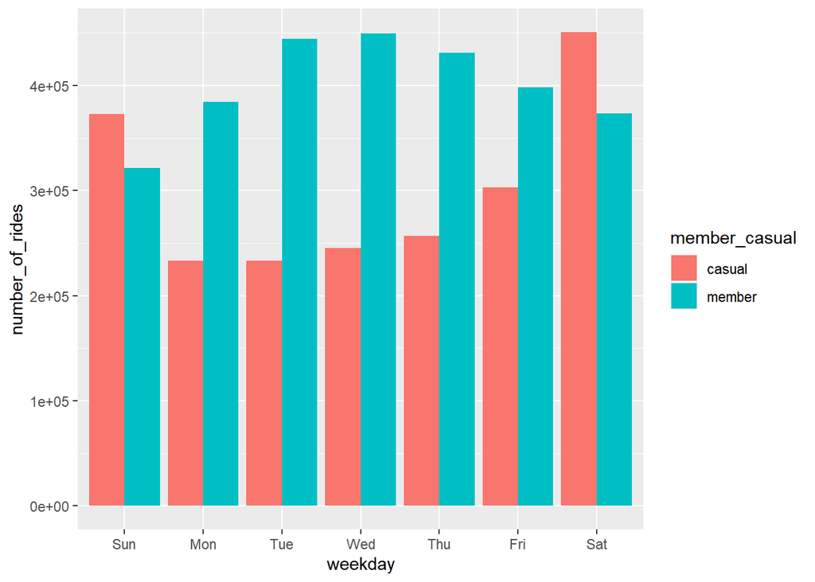

```r
twelve_months3 %>%
  mutate(weekday = wday(started_at, label = TRUE)) %>%
  group_by(member_casual, weekday) %>%
  summarise(number_of_rides = n()
            ,average_duration = mean(ride_length)) %>%
  arrange(member_casual, weekday)  %>%
  ggplot(aes(x = weekday, y = number_of_rides, fill = member_casual)) +
  geom_col(position = "dodge")
```

#### comparison of Average duration annual members and casual riders

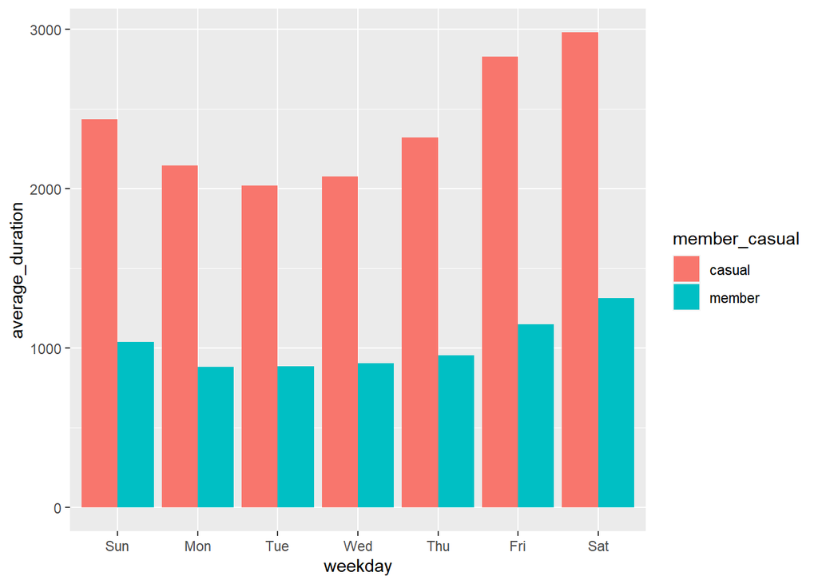

```r
twelve_months3 %>%
  mutate(weekday = wday(started_at, label = TRUE)) %>%
  group_by(member_casual, weekday) %>%
  summarise(number_of_rides = n()
            ,average_duration = mean(ride_length)) %>%
  arrange(member_casual, weekday)  %>%
  ggplot(aes(x = weekday, y = average_duration, fill = member_casual)) +
  geom_col(position = "dodge")
```

#### Comparison of average duraation of ride for casual and annual riders in each month

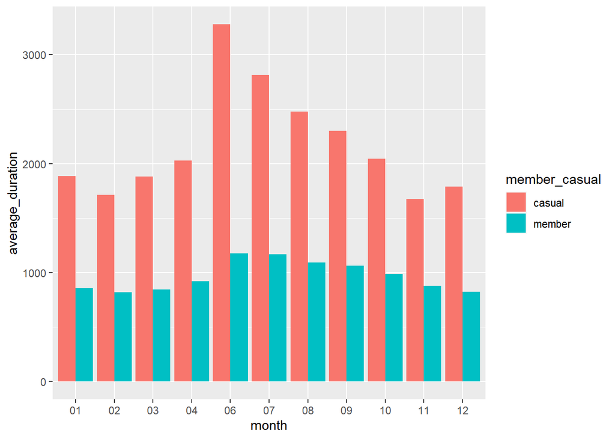

```r
twelve_months3 %>%
  group_by(member_casual, month) %>%
  summarise(number_of_rides = n()
            ,average_duration = mean(ride_length)) %>%
  arrange(member_casual, month)  %>%
  ggplot(aes(x = month, y = average_duration, fill = member_casual)) +
  geom_col(position = "dodge")
```

### comparison of number of rides for casual and annual riders in each month

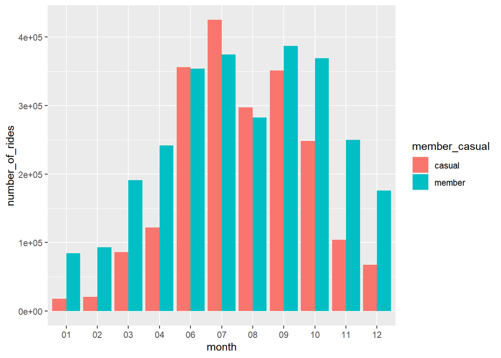

```r
twelve_months3 %>%
  group_by(member_casual, month) %>%
  summarise(number_of_rides = n()
            ,average_duration = mean(ride_length)) %>%
  arrange(member_casual, month)  %>%
  ggplot(aes(x =month, y = number_of_rides, fill = member_casual)) +
  geom_col(position = "dodge")
```

Conclusions

Overall, there are more annual members than casual members using cyclistic.

Casual riders tend to use Cyclistic for longer period of time than annual members do.

Casual riders use cyclsitic about the same or slightly more during the weekend but annual members use cyclstic more during the week. One possible cause of this is that annual members use cyclistic for work whereas casual riders use it more for fun.

Although, the data collected provides some insights to how annual and casual riders use cyclistic differently such as insights on ride length, the rider ID throughout the twelve months tend to only appear once. It is unclear if this is because new rider id is given every time riders use Cyclsitic or if it implies riders only use Cyclstic once during the twelve month. Knowing how frequently, individuals use the application could better help us understand differences between the two.

## Act

Recommendations:

Considering, casual riders use cyclistic most during weekend and during summer months, the company should offer promotion during these months and days to convince casual riders to convert to annual members.

Considering the overall goal of the company is to increase profit, the company should do an analysis of its profit changes over the last three years. In the analysis they should compare how changes in number of annual and casual riders have impacted profits. they can also see how many new casual and annual riders they get per year and how many casual members shift their membership. This analysis would help them determine if targeting casual members to get them to switch to annual members is the best approach or if company could make more profit using another method.